# Настройка NAT

Лабораторная работа №12

Илья Колонтырский

Российский университет дружбы народов, Москва, Россия

26.04.2026

# Цели и задачи работы

## Цель лабораторной работы

Приобрести практические навыки настройки доступа локальной сети организации к внешней сети с использованием технологии **NAT**.

## Задачи

- Выполнить первоначальную настройку оборудования провайдера.
- Настроить интерфейсы маршрутизатора и коммутатора провайдера.
- Подключить маршрутизатор сети «Донская» к сети провайдера.
- Настроить NAT для выхода локальной сети во внешнюю сеть.
- Настроить доступ из внешней сети к внутренним серверам.
- Проверить корректность правил доступа и трансляции адресов.

# Настройка оборудования провайдера

## Первоначальная настройка provider-gw-1

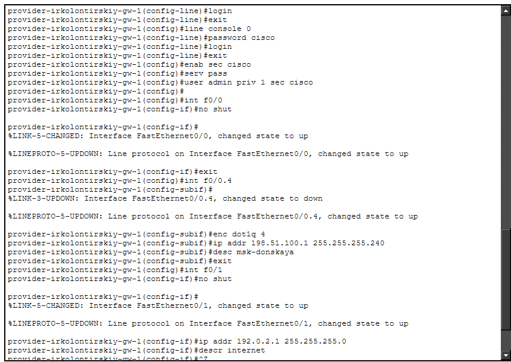

Первоначальная настройка маршрутизатора provider-gw-1

## Настройка provider-sw-1

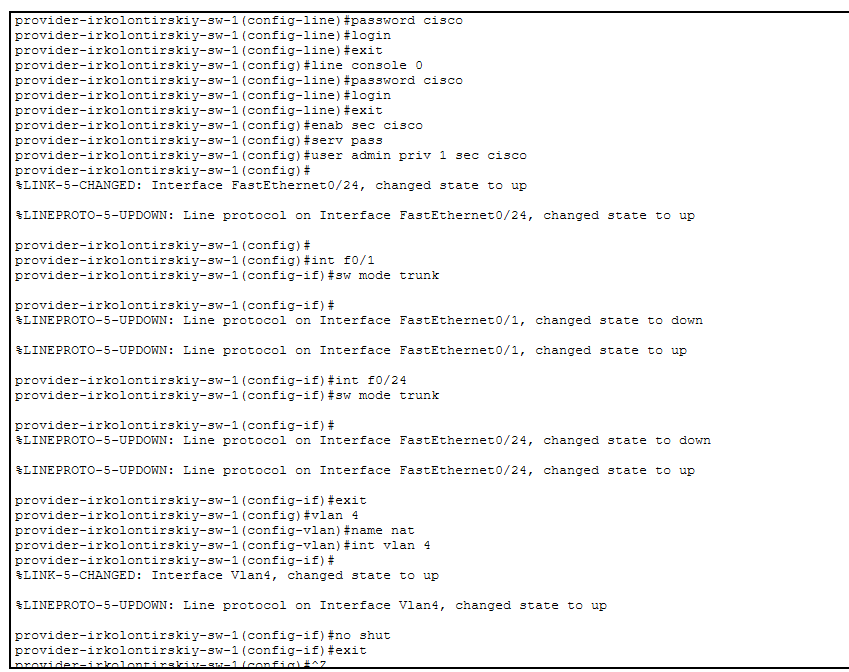

Настройка коммутатора provider-sw-1 и VLAN 4

# Подключение сети «Донская»

## Настройка внешнего интерфейса маршрутизатора

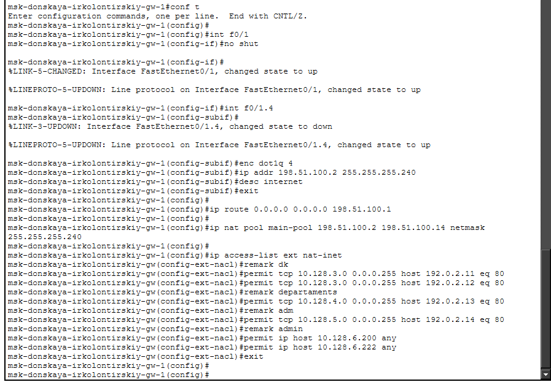

Настройка внешнего интерфейса маршрутизатора сети «Донская»

# Настройка NAT

## Основные параметры NAT

Для выхода локальной сети во внешнюю сеть был настроен NAT overload:

- создан ACL **nat-inet**
- создан пул внешних адресов **main-pool**
- диапазон пула: **198.51.100.2–198.51.100.14**
- маска: **255.255.255.240**
- внутренние интерфейсы отмечены как **ip nat inside**
- внешний интерфейс отмечен как **ip nat outside**

## Настройка NAT overload

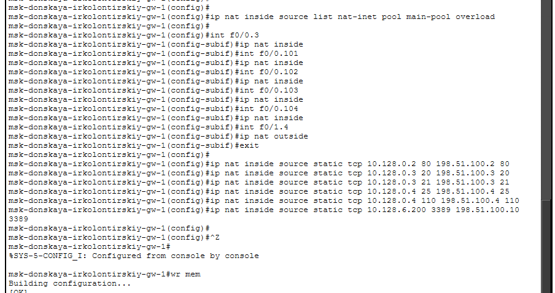

Настройка NAT overload и обозначение NAT-интерфейсов

## Статические NAT-преобразования

Для публикации внутренних сервисов были настроены статические NAT-правила:

| Сервис | Внутренний адрес | Внешний адрес | Порт |
| --- | --- | --- | --- |
| WEB | 10.128.0.2 | 198.51.100.2 | 80 |
| FTP | 10.128.0.3 | 198.51.100.3 | 21 |
| SMTP | 10.128.0.4 | 198.51.100.4 | 25 |
| POP3 | 10.128.0.4 | 198.51.100.4 | 110 |
| RDP | 10.128.6.200 | 198.51.100.10 | 3389 |

# Проверка доступа пользователей

## Проверка сети дисплейных классов

Для устройства **dk-donskaya-irkolontirskiy-1** проверен доступ к разрешённым и запрещённым ресурсам.

- **www.rudn.ru** — доступ запрещён
- **www.yandex.ru** — доступ разрешён
- **stud.rudn.university** — доступ разрешён

## Запрет доступа к www.rudn.ru

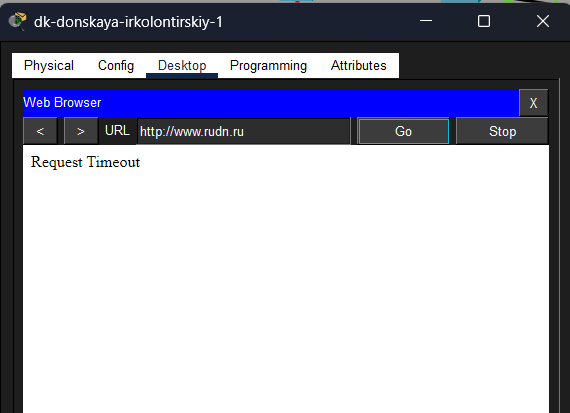

Проверка запрета доступа к сайту www.rudn.ru из сети дисплейных классов

## Доступ к www.yandex.ru

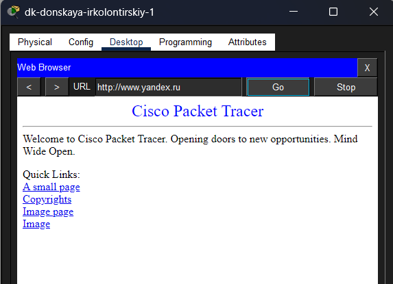

Проверка доступа к сайту www.yandex.ru из сети дисплейных классов

## Доступ к stud.rudn.university

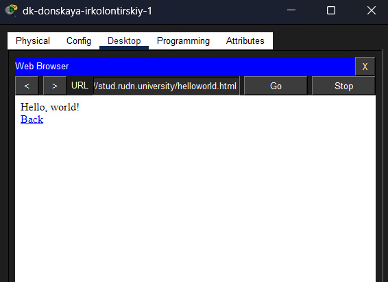

Проверка доступа к сайту stud.rudn.university из сети дисплейных классов

## Проверка сети кафедр

Для устройства **dep-donskaya-irkolontirskiy-1** проверен доступ к образовательному ресурсу **esystem.pfur.ru**.

Страница открылась успешно, что подтверждает корректность правила доступа для пользователей сети кафедр.

## Доступ к esystem.pfur.ru

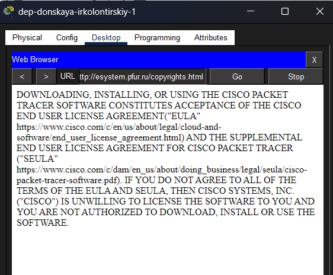

Проверка доступа к сайту esystem.pfur.ru из сети кафедр

## Проверка сети администрации

Для устройства **adm-donskaya-irkolontirskiy-1** проверен доступ к сайту университета **www.rudn.ru**.

Страница с изображением открылась успешно, следовательно правило доступа для сети администрации работает корректно.

## Доступ к www.rudn.ru

[figure not shown]

Проверка доступа к сайту www.rudn.ru из сети администрации

## Проверка доступа администратора

Для компьютера **admin-donskaya-irkolontirskiy-1** проверен полный доступ во внешнюю сеть.

Изображение с сайта **www.yandex.ru** было успешно загружено.

## Полный доступ администратора

[figure not shown]

Проверка полного доступа администратора во внешнюю сеть

## Проверка сети других пользователей

Для устройства **other-donskaya-irkolontirskiy-1** выполнена попытка обращения к **www.rudn.ru**.

Получен результат **Host Name Unresolved**, что подтверждает запрет выхода в Интернет для данного сегмента.

## Запрет доступа для других пользователей

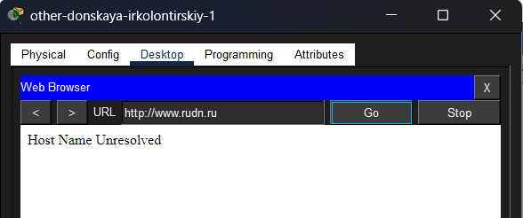

Проверка запрета выхода в Интернет для других пользователей

# Проверка доступности серверов

## Настройка внешнего клиента

Для проверки доступа к опубликованным сервисам использовалось устройство **user-irkolontirskiy**.

Параметры клиента:

- IP-адрес: **192.0.2.20**
- Маска: **255.255.255.0**
- Шлюз: **192.0.2.1**

## Настройка IP-адреса клиента

[figure not shown]

Настройка IP-адреса клиентского устройства

## Проверка WEB-сервера

WEB-сервер должен быть доступен извне по порту **80**.

При обращении к адресу **198.51.100.2** страница успешно открылась, что подтверждает работу статического NAT для WEB-сервера.

## Доступ к WEB-серверу

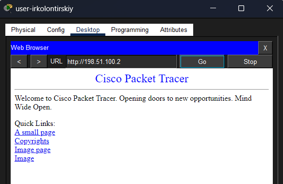

Проверка доступа к WEB-серверу по порту 80

## Проверка FTP-сервера

FTP-сервер должен быть доступен извне по портам протокола FTP.

Подключение к адресу **198.51.100.3** выполнено успешно, авторизация прошла корректно, список файлов был получен.

## Доступ к FTP-серверу

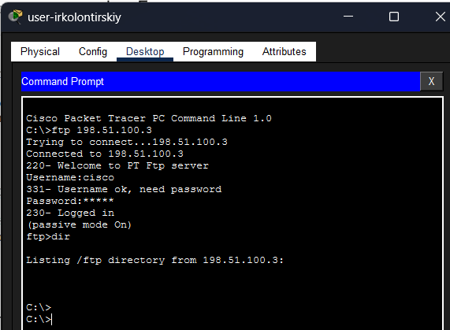

Проверка доступа к FTP-серверу

## Проверка почтового сервера

Почтовый сервер должен быть доступен извне по портам:

- **25** — SMTP
- **110** — POP3

На клиенте настроен почтовый ящик с использованием сервера **198.51.100.4**.

## Настройка почтового клиента

[figure not shown]

Настройка почтового клиента

## Получение почты

Письмо было успешно получено с POP3-сервера, что подтверждает доступность почтового сервера по заданным портам.

## Проверка работы почтового сервера

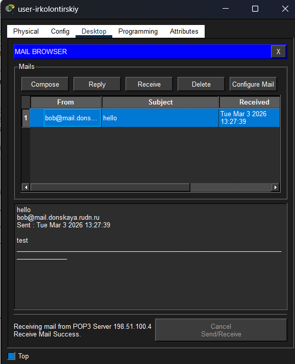

Проверка работы почтового сервера

# Выводы

## Вывод

В ходе лабораторной работы была выполнена настройка подключения локальной сети организации к сети провайдера с использованием технологии **NAT**.

Были настроены:

- маршрутизатор и коммутатор провайдера;
- внешний интерфейс маршрутизатора сети «Донская»;
- маршрут по умолчанию;
- NAT overload для выхода во внешнюю сеть;
- статические NAT-преобразования для серверов;
- правила ограничения доступа пользователей.